# Notebook

To get started you need to sign up for a regular Twitter account as well as a Twitter developer account.

Twitter uses the OAuth 1.0 protocol for authentication when an app (or bot in our case) makes api calls.

The Client / Consumer = our bot. The Service Provider = Twitter. The Resource Owner = the Twitter users that our bot will be gathering tweet data from.

The OAuth protocol performs a kind of three-legged dance:

1. The client obtains an unauthorized request token from the service provider.
2. The resource owner authorizes the request token.
3. The client exchanges the request token for an access token.
4. The client uses the access token to access protected resources on behalf of the resource owner

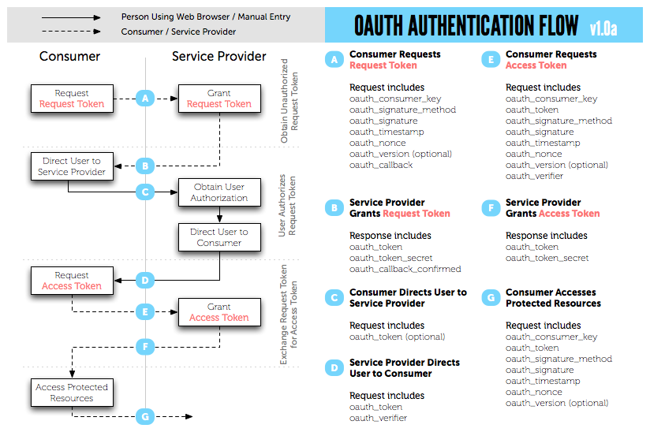

```python
from IPython.display import Image
Image(filename='/Users/cem/Documents/csun/classes/math/582d/unit2-text/twitter/oauth_diagram.png')
```

```python
import twitter


# XXX: Go to http://dev.twitter.com/apps/new to create an app and get values
# for these credentials, which you'll need to provide in place of these
# empty string values that are defined as placeholders.
# See https://dev.twitter.com/docs/auth/oauth for more information
# on Twitter's OAuth implementation.

CONSUMER_KEY = ''
CONSUMER_SECRET =''
OAUTH_TOKEN = ''
OAUTH_TOKEN_SECRET = ''

auth = twitter.oauth.OAuth(OAUTH_TOKEN, OAUTH_TOKEN_SECRET,
                           CONSUMER_KEY, CONSUMER_SECRET)

t = twitter.Twitter(auth=auth)
print t
```

```
<twitter.api.Twitter object at 0x1049e6a90>
```

```python
t.statuses.home_timeline()[0]
```

```
{u'contributors': None,
 u'coordinates': None,
 u'created_at': u'Wed Oct 22 19:41:13 +0000 2014',
 u'entities': {u'hashtags': [],
  u'symbols': [],
  u'urls': [{u'display_url': u'p4k.in/1tcyHDr',
    u'expanded_url': u'http://p4k.in/1tcyHDr',
    u'indices': [92, 114],
    u'url': u'http://t.co/KymnQySILV'}],
  u'user_mentions': [{u'id': 19028953,
    u'id_str': u'19028953',
    u'indices': [19, 27],
    u'name': u'J. Cole',
    u'screen_name': u'JColeNC'},
   {u'id': 115633811,
    u'id_str': u'115633811',
    u'indices': [48, 59],
    u'name': u'Jessie Ware',
    u'screen_name': u'JessieWare'}]},
 u'favorite_count': 11,
 u'favorited': False,
 u'geo': None,
 u'id': 525008994872872961,
 u'id_str': u'525008994872872961',
 u'in_reply_to_screen_name': None,
 u'in_reply_to_status_id': None,
 u'in_reply_to_status_id_str': None,
 u'in_reply_to_user_id': None,
 u'in_reply_to_user_id_str': None,
 u'lang': u'en',
 u'place': None,
 u'possibly_sensitive': False,
 u'retweet_count': 4,
 u'retweeted': False,
 u'source': u'<a href="https://about.twitter.com/products/tweetdeck" rel="nofollow">TweetDeck</a>',
 u'text': u'Listen to J. Cole (@JColeNC) jump on a remix of @JessieWare\'s "Kind of...Sometimes...Maybe" http://t.co/KymnQySILV',
 u'truncated': False,
 u'user': {u'contributors_enabled': False,
  u'created_at': u'Thu Mar 06 15:34:41 +0000 2008',
  u'default_profile': False,
```

[output cut: 26 more lines]

```
  u'profile_banner_url': u'https://pbs.twimg.com/profile_banners/14089195/1406061043',
  u'profile_image_url': u'http://pbs.twimg.com/profile_images/460905192754397184/foVYUDGD_normal.jpeg',
  u'profile_image_url_https': u'https://pbs.twimg.com/profile_images/460905192754397184/foVYUDGD_normal.jpeg',
  u'profile_link_color': u'EF4035',
  u'profile_sidebar_border_color': u'FFFFFF',
  u'profile_sidebar_fill_color': u'171717',
  u'profile_text_color': u'456E87',
  u'profile_use_background_image': True,
  u'protected': False,
  u'screen_name': u'pitchfork',
  u'statuses_count': 37253,
  u'time_zone': u'Eastern Time (US & Canada)',
  u'url': u'http://t.co/qq2gaKn1lk',
  u'utc_offset': -14400,
  u'verified': True}}
```

Twitter has number of APIs, but we'll mainly concern ourselves with the REST API and the Streaming API

What is REST? REST ('Representational State Transfer) is a bit like a command line where the service is the computer. RESTful APIs enable developers to access information and resources using a simple HTTP invocation. You can obtain domain-specific data simply by pointing a URL to a specific location.

So, the Twitter Search API is a RESTful service that enables users to point to a specific URL and retrieve a variety of tweets that meet the criteria specified in the URL. This enables you, as a developer, to accept input within a Web application and dynamically query Twitter based on that input, using a simple URL that encodes the input into a format that the API understands.

Using the Twitter REST API, we can access profiles, make updates, get followers, add followers, do search.

Take a look at the https://dev.twitter.com/overview/api/ to get a breakdown of tweet attributes, user attributes

```python
# Get a particular friend's timeline
t.statuses.user_timeline(screen_name="billybob")

# to pass in GET/POST parameters, such as `count`
t.statuses.home_timeline(count=5)

# to pass in the GET/POST parameter `id` you need to use `_id`
t.statuses.oembed(_id=1234567890)
# get the ids of your followers
t.followers.ids()
# Update your status
t.statuses.update(
    status="Using @sixohsix's sweet Python Twitter Tools.")
# See https://pypi.python.org/pypi/twitter for other usages.
t.statuses.update(status="Panda vs Putin--Bring it on")
```

See https://dev.twitter.com/rest/public/rate-limits for limits on how many calls your api can make in a time frame. We'll do a twitter search below. Twitter Search api limits you to the past 6-9 days of data. Also see https://dev.twitter.com/rest/public/search for different kinds of search parameters

```python
import json
lq="ebola obama"
count = 100

# See https://dev.twitter.com/docs/api/1.1/get/search/tweets

search_results = t.search.tweets(q=lq, count=count,lang='en')
json.dumps(search_results, indent=1)
#print "==================================================================="

statuses = search_results['statuses']
```

```python
# Iterate through 5 more batches of results by following the cursor

n = 10
for _ in range(n):
    print "Length of statuses", len(statuses)
    try:
        next_results = search_results['search_metadata']['next_results']
    except KeyError, e: # No more results when next_results doesn't exist
        break

    # Create a dictionary from next_results, which has the following form:
    # ?max_id=313519052523986943&q=NCAA&include_entities=1
    kwargs = dict([ kv.split('=') for kv in next_results[1:].split("&") ])
   # print kwargs

    search_results = t.search.tweets(**kwargs)
    statuses += search_results['statuses']

# Show one sample search result by slicing the list...
#print json.dumps(statuses[1]['text'], indent=1)

statuses[0]['text']
```

```
Length of statuses 200
```

```
u'RT @PatDollard: JUDICIAL WATCH-Obama To Bring Non-American Ebola Victims To The U.S. For Treatment http://t.co/ESoXwTOVs2  #lnyhbt #teapart\u2026'
```

```python
screen_names = [ user_mention['screen_name']
                 for status in statuses
                     for user_mention in status['entities']['user_mentions'] ]
hashtags = [ hashtag['text']
             for status in statuses
                 for hashtag in status['entities']['hashtags'] ]
print hashtags
```

```
[u'Democrats', u'attempt', u'blame', u'Republican', u'Ebola', u'obama', u'3tking', u'congress', u'Ebola', u'obama', u'Ebola', u'NFL', u'Washington', u'News', u'Ebola', u'Obama', u'news', u'Ebola', u'TCOT', u'p2', u'p2b', u'ctl', u'Ebola', u'EVDFree', u'Ebola', u'EBOLA', u'Ebola', u'EVDFree', u'Ebola…
```

```python
from prettytable import PrettyTable
from collections import Counter

retweets = [
            # Store out a tuple of these three values ...
            (status['retweet_count'],
             status['retweeted_status']['user']['screen_name'],
             status['id'],
             status['text'])

            # ... for each status ...
            for status in statuses

            # ... so long as the status meets this condition.
            if status.has_key('retweeted_status')
           ]

pt = PrettyTable(field_names=['Count', 'Screen Name', 'id','Text'])
[ pt.add_row(row) for row in sorted(retweets, reverse=True)[:4] ]
pt.max_width['Text'] = 50
pt.align= 'l'
print pt
```

```
+-------+---------------+--------------------+----------------------------------------------------+
| Count | Screen Name   | id                 | Text                                               |
+-------+---------------+--------------------+----------------------------------------------------+
| 16378 | dangitobama   | 525009821788299266 | RT @dangitobama: Ebola wasn't in the US when Bush  |
|       |               |                    | was president... THANKS OBAMA.                     |
| 6674  | JohnFugelsang | 525010402967838720 | RT @JohnFugelsang: Remember when Ebola killed      |
|       |               |                    | thousands of Americans and Obama wouldn't even     |
|       |               |                    | mention it?  Oh wait, that was AIDS and Reagan…    |
| 6674  | JohnFugelsang | 525007859277631492 | RT @JohnFugelsang: Remember when Ebola killed      |
|       |               |                    | thousands of Americans and Obama wouldn't even     |
|       |               |                    | mention it?  Oh wait, that was AIDS and Reagan…    |
| 4319  | CloydRivers   | 525012812217974785 | RT @CloydRivers: We're fightin' Ebola and ISIS.    |
|       |               |                    | Meanwhile, the First Lady is dancin' with a        |
|       |               |                    | turnip. And y'all elected Obama? Twice.            |
|       |               |                    | https:/…                                           |
+-------+---------------+--------------------+----------------------------------------------------+
```

```python
t.users.show(screen_name="dangitobama ")[u'description']
```

```
u'(Original Parody Account) Business: BrickCh4News@yahoo.com Kik: DangItObama'
```

```python
import nltk
nltk.data.path.append('/Users/cem/Documents/_code/nltk')

from nltk.corpus import stopwords
import string

stop = stopwords.words('english') + ['ebola','cdc','obama','rt']
```

```python
status_texts = [i['text'] for i in statuses]
words = [ w.lower().replace('@','')
          for t in status_texts
              for w in t.split() ]

words = [w.replace('#','') for w in words if w not in stop]
c = Counter(words)
c.most_common()[:30]
```

```
[(u'sick', 60),
 (u'.', 39),
 (u'czar', 24),
 (u'ebola', 24),
 (u'travel', 21),
 (u"obama's", 21),
 (u'obama\u2019s', 20),
 (u'us', 19),
 (u'obama,', 19),
 (u'ebola,', 19),
 (u'administration', 16),
 (u'isis,', 16),
 (u'thanks', 16),
 (u'tcot', 15),
 (u'-', 15),
 (u'4', 15),
 (u'dallas', 14),
 (u'elections,', 13),
 (u'hospital', 13),
 (u'waynedupreeshow:', 12),
 (u'tools', 12),
 (u'\u2026', 12),
 (u'watching', 12),
 (u'minorities', 12),
 (u'used', 12),
 (u'calls,', 12),
 (u'i\u2019m', 12),
 (u'liber\u2026', 12),
 (u'president', 11),
 (u'restrictions', 11)]
```

This was a flyby of the Twitter RESTful API. You may also want to check out the Streaming API: https://dev.twitter.com/streaming/overview

```python
twitter_stream = twitter.TwitterStream(auth=auth)
stream = twitter_stream.statuses.filter(track="ebola")
```

```python
tweet = stream.next()
print tweet['text']
```

```
Ebola: Rwanda Introduces Screening for Visitors From US and Span http://t.co/xaxE1RNbLA
```

```python
import io
with io.open("obama_ebola.json", 'w', encoding='utf-8', buffering=1) as f:
    for tweet in stream:
        f.write(unicode(u'{0}\n'.format(json.dumps(tweet, ensure_ascii=False))))
        #print tweet['text']
```